# SMS Spam Detection Case Study

Bu projede SMS mesajlarını **spam** ve **ham** (spam olmayan) olarak sınıflandıracağız. Görevde yalnızca `sms_spam_train.csv` dosyası gönderildiğinden, veriyi yükleyip eğitim ve test setlerine ayırarak modeli geliştireceğiz.

# İçindekiler

- SMS Spam Detection Case Study
- Adım 1: Gerekli Kütüphanelerin Import Edilmesi
- Adım 2: EDA
  - 2.1 Veri Setinin Yüklenmesi ve İlk İnceleme
  - 2.2 Veri Seti Bilgileri ve Eksik Değerler
  - 2.3 Etiket (Label) Dağılımı
  - 2.4 Mesaj Uzunluğu ve Kelime Sayısı Analizi
  - 2.5 WordCloud ile Görselleştirme
  - 2.6 En Sık Kullanılan Kelimeler Analizi
- Adım 3: Veri Temizleme ve Metin Ön İşleme
  - 3.1 Metin Temizleme Fonksiyonu Oluşturma
  - 3.2 Temizlenmiş Mesaj Sütunu Oluşturma
- Adım 4: Özellik Çıkarımı
  - 4.1 TF-IDF Vektörleştirme
  - 4.2 Etiketlerin Kodlanması
- Adım 5: Modelleme ve Değerlendirme
  - 5.1 TF-IDF Verisini PyCaret’e Uyumlu Hale Getirme ve Setup
  - 5.2 Model Karşılaştırması ve Seçimi
  - 5.3 Tuning İşlemleri
  - 5.4 Model Değerlendirme ve Görselleştirme
  - 5.5 Final Modelin Oluşturulması ve Kaydedilmesi

[figure not shown]

## Adım 1: Gerekli Kütüphanelerin Import Edilmesi

Aşağıdaki kod bloğunda, veri işleme, görselleştirme, metin ön işleme ve modelleme için gerekli kütüphaneleri yüklüyoruz.

```python
# Veri işleme ve görselleştirme
import numpy as np
import pandas as pd
import matplotlib.pyplot as plt
import seaborn as sns

# Modelleme ve değerlendirme
from sklearn.model_selection import train_test_split
from sklearn.feature_extraction.text import TfidfVectorizer
from sklearn.linear_model import LogisticRegression
from sklearn.metrics import classification_report, confusion_matrix

# Metin ön işleme
import re
import nltk
nltk.download('stopwords')
from nltk.corpus import stopwords

# Eğer gerekirse diğer kütüphaneleri de ekleyin.
```

## Adım 2: EDA

### 2.1 Veri Setinin Yüklenmesi ve İlk İnceleme

Bu bölümde, `sms_spam_train.csv` dosyasını okuyup veri setimizin temel özelliklerini (boyut, sütun isimleri, ilk birkaç satır) inceleyeceğiz.

```python
import os
from pathlib import Path
import pandas as pd

# Mevcut çalışma dizini: "C:\Users\Hakan\Downloads\sms_spam_detection\teknasyon-case-ai-datascientist\notebooks"
# Veri "datasets" klasörü ise, notebooks klasörünün üst dizininde bulunuyorsa:
base_dir = Path.cwd().parent  # Çalışma dizininin (notebooks) üst dizinine geçer.
dataset_path = base_dir / "datasets" / "sms_spam_train.csv"
df = pd.read_csv(dataset_path)
```

### 2.2 Veri Seti Bilgileri ve Eksik Değerler

Veri setimizin sütun tiplerini, eksik değer durumunu ve genel bilgilerini inceleyelim.

```python
# Veri setinin genel bilgilerini görüntüleyelim
df.info()

# Eksik değer kontrolü
print("Eksik Değer Sayıları:")
print(df.isnull().sum())
```

```
<class 'pandas.core.frame.DataFrame'>
RangeIndex: 10000 entries, 0 to 9999
Data columns (total 2 columns):
 #   Column   Non-Null Count  Dtype
---  ------   --------------  -----
 0   Message  10000 non-null  object
 1   Label    10000 non-null  object
dtypes: object(2)
memory usage: 156.4+ KB
Eksik Değer Sayıları:
Message    0
Label      0
dtype: int64
```

Veri Seti Boyutu: Kod çıktısına göre veri setimiz (10000, 2) boyutunda; yani 10.000 satır ve 2 sütundan oluşuyor. Bu, yeterli sayıda örnek içeren orta büyüklükte bir veri seti olduğunu gösteriyor.

Sütunlar: Sütun isimleri "Message" ve "Label" olarak belirlenmiş.

Örneğin, ilk mesaj "Whats upp ac enisteee: -) senin memlekette bul..." olarak listelenmiş ve etiketi "ham" olarak belirtilmiş. İkinci satırda ise bir kampanya mesajı var ve etiketi "spam" olarak gözüküyor.

### 2.3 Etiket (Label) Dağılımı

Mesajların 'ham' ve 'spam' olarak dağılımını sayısal ve görsel olarak inceleyelim.

```
Etiket Dağılımı:
 Label
ham     6621
spam    3379
Name: count, dtype: int64
```

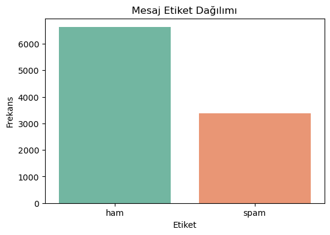

```python
import matplotlib.pyplot as plt
import seaborn as sns

# Etiket dağılımını sayısal olarak görüntüleyelim
label_counts = df['Label'].value_counts()
print("Etiket Dağılımı:\n", label_counts)

# Etiket dağılımını görselleştirelim
plt.figure(figsize=(6,4))
sns.countplot(x='Label', data=df, palette="Set2")
plt.title("Mesaj Etiket Dağılımı")
plt.xlabel("Etiket")
plt.ylabel("Frekans")
plt.show()
```

Veri seti dengesiz de olsa (2’ye 1 oranında), her iki sınıftan da yeterli örnek bulunuyor. “Spam” sınıfının, “ham” sınıfına oranla daha az olduğu ancak yine de makul miktarda örnek içerdiği görülüyor. Bu dengesizlik, modelleme aşamasında (ör. sınıflandırma hata metriği veya SMOTE vb. tekniklerle) dikkate alınabilir.

### 2.4 Mesaj Uzunluğu ve Kelime Sayısı Analizi

Mesajların karakter uzunluklarını ve kelime sayılarını hesaplayıp, genel dağılımı ve etiketlere göre karşılaştırmalar yapacağız.

```python
# Mesaj uzunluğu ve kelime sayısını hesaplayıp yeni sütunlar ekleyelim
df['Message_Length'] = df['Message'].apply(len)
df['Word_Count'] = df['Message'].apply(lambda x: len(x.split()))

# İlk birkaç satırı kontrol edelim
df[['Message', 'Message_Length', 'Word_Count']].head()
```

|  | Message | Message_Length | Word_Count |
| --- | --- | --- | --- |
| 0 | Whats upp ac enisteee: -) senin memlekette bul... | 51 | 8 |
| 1 | Kampanya, VakifBank Worldcardla 31 Mayisa kada... | 228 | 34 |
| 2 | I wont. So wat's wit the guys | 29 | 7 |
| 3 | Bu arada son dakika evi düşürdük | 32 | 6 |
| 4 | No that just means you have a fat head | 38 | 9 |

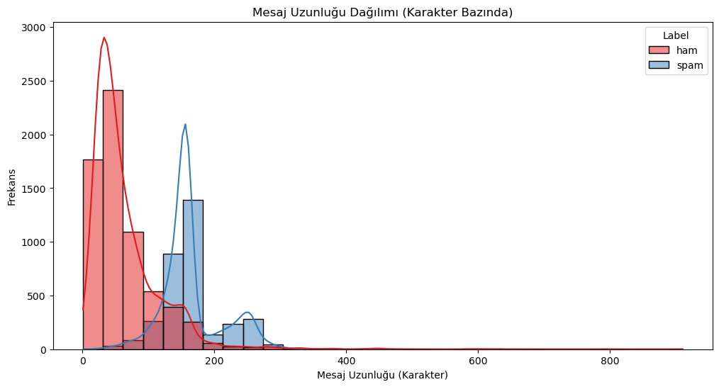

```python
plt.figure(figsize=(12,6))
sns.histplot(data=df, x='Message_Length', hue='Label', kde=True, bins=30, palette="Set1")
plt.title("Mesaj Uzunluğu Dağılımı (Karakter Bazında)")
plt.xlabel("Mesaj Uzunluğu (Karakter)")
plt.ylabel("Frekans")
plt.show()
```

Spam mesajlar, tanıtım metinleri, linkler ya da kampanya detayları gibi daha fazla içerik barındırdığı için karakter sayısı ortalama olarak daha yüksek.

Ham mesajların önemli bir kısmı kısa sohbet mesajları veya günlük konuşma dillerinde yazıldığı için ortalama karakter sayısı daha düşük.

Karakter uzunluğu, spam tespiti açısından önemli bir öz nitelik (feature) olabilir.

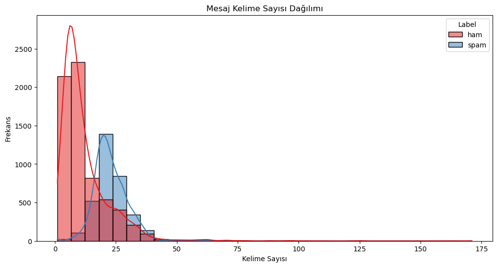

```python
plt.figure(figsize=(12,6))
sns.histplot(data=df, x='Word_Count', hue='Label', kde=True, bins=30, palette="Set1")
plt.title("Mesaj Kelime Sayısı Dağılımı")
plt.xlabel("Kelime Sayısı")
plt.ylabel("Frekans")
plt.show()
```

Benzer şekilde, spam mesajlar uzun ve çok kelimeli olma eğiliminde.

“Ham” mesajlarda ise sohbet mesajları, kısa cevaplar vb. yaygın olduğu için kelime sayısının düşük olduğu görülüyor.

Bu da modelin ayırt edici özelliklerinden biri olarak değerlendirilebilir.

### 2.5 WordCloud ile Görselleştirme

Spam ve ham mesajlar için ayrı ayrı word cloud (kelime bulutu) oluşturarak, hangi kelimelerin öne çıktığını görselleştireceğiz.

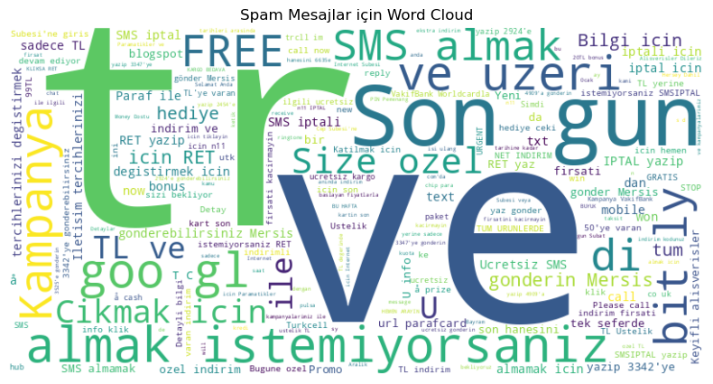

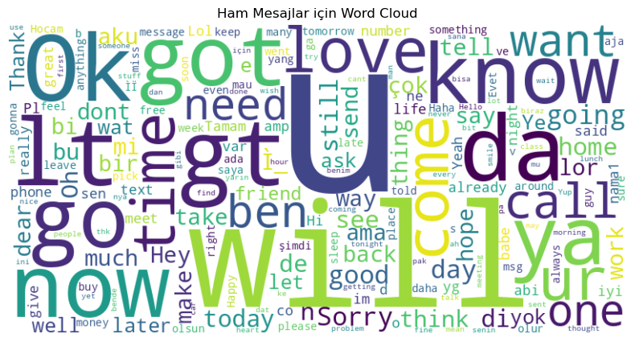

```python
from wordcloud import WordCloud, STOPWORDS

# Spam mesajlar için word cloud oluşturma
spam_text = " ".join(df[df['Label'] == 'spam']['Message'].tolist())
wordcloud_spam = WordCloud(width=800, height=400, background_color='white', stopwords=STOPWORDS).generate(spam_text)

plt.figure(figsize=(10, 5))
plt.imshow(wordcloud_spam, interpolation='bilinear')
plt.axis('off')
plt.title("Spam Mesajlar için Word Cloud")
plt.show()

# Ham mesajlar için word cloud oluşturma
ham_text = " ".join(df[df['Label'] == 'ham']['Message'].tolist())
wordcloud_ham = WordCloud(width=800, height=400, background_color='white', stopwords=STOPWORDS).generate(ham_text)

plt.figure(figsize=(10, 5))
plt.imshow(wordcloud_ham, interpolation='bilinear')
plt.axis('off')
plt.title("Ham Mesajlar için Word Cloud")
plt.show()
```

Spam mesajlarda sık geçen kelimeler kampanya, promosyon ve link odaklı (free, son gün, sms, kampanya, bitly vb.).

Türkçe spam içeriklerinde “kampanya”, “almak”, “son gün” gibi aciliyet veya fırsat hissi yaratan sözcüklerin belirgin olduğu görülüyor.

Ham (normal) mesajların daha sohbet havasında, kısaltmalar ve gündelik ifadeler içerdiği anlaşılıyor (ör: “ok”, “u” / “you”, “know”, “like” vb.).

Bu kelime bulutu, ham mesajların yapısının spam mesajlardan farklılaştığını açıkça gösteriyor.

### 2.6 En Sık Kullanılan Kelimeler Analizi

Spam ve ham mesajlarda en sık kullanılan kelimeleri analiz ederek, mesajların dil yapısı hakkında fikir edineceğiz. Bu aşamada mesajları tokenize edip, stop-word'leri çıkardıktan sonra en sık geçen kelimeleri sayacağız.

```python
import nltk
from nltk.tokenize import word_tokenize
from collections import Counter

# Gerekli NLTK paketlerini indiriyoruz (önceden indirilmediyse)
nltk.download('punkt_tab')
nltk.download('stopwords')

# İngilizce stop-word'ler
stop_words = set(nltk.corpus.stopwords.words('english'))

# Spam mesajlar için en sık kullanılan kelimeleri bulma
spam_words = []
for message in df[df['Label'] == 'spam']['Message']:
    tokens = word_tokenize(message.lower())
    spam_words.extend([token for token in tokens if token.isalpha() and token not in stop_words])

spam_freq = Counter(spam_words)
print("Spam Mesajlarda En Sık Kullanılan 10 Kelime:")
print(spam_freq.most_common(10))

# Ham mesajlar için en sık kullanılan kelimeleri bulma
ham_words = []
for message in df[df['Label'] == 'ham']['Message']:
    tokens = word_tokenize(message.lower())
    ham_words.extend([token for token in tokens if token.isalpha() and token not in stop_words])

ham_freq = Counter(ham_words)
print("\nHam Mesajlarda En Sık Kullanılan 10 Kelime:")
print(ham_freq.most_common(10))
```

```
Spam Mesajlarda En Sık Kullanılan 10 Kelime:
[('icin', 1088), ('tl', 846), ('sms', 682), ('http', 579), ('indirim', 560), ('yazip', 533), ('ozel', 478), ('son', 435), ('e', 413), ('ile', 365)]

Ham Mesajlarda En Sık Kullanılan 10 Kelime:
[('u', 866), ('gt', 299), ('lt', 285), ('get', 262), ('da', 245), ('ok', 229), ('got', 219), ('know', 212), ('go', 211), ('like', 206)]
```

## Adım 3: Veri Temizleme ve Metin Ön İşleme

### 3.1 Metin Temizleme Fonksiyonu Oluşturma

Bu bölümde, metin verilerindeki gereksiz karakterleri, noktalama işaretlerini ve stop-word’leri (hem İngilizce hem Türkçe) temizleyecek bir fonksiyon oluşturacağız.  
Fonksiyonumuz:

- Metni küçük harfe çevirir,
- Türkçe karakterler de dahil olmak üzere yalnızca alfanümerik karakterler ve boşlukları korur,
- Fazla boşlukları tek boşluğa indirger,
- Token’lara ayırır ve stop-word’leri temizler.

```python
import re
import nltk
nltk.download('stopwords')
from nltk.corpus import stopwords

# Türkçe stop-word'lerden oluşan kısmi bir liste (isteğe bağlı olarak geliştirilebilir)
turkish_stopwords = {
    "acaba", "ama", "aslında", "az", "bazı", "belki", "biri", "birkaç", "birçok",
    "bu", "çok", "çünkü", "da", "de", "daha", "eğer", "en", "gibi", "hem", "hep",
    "hepsi", "için", "ile", "ise", "kim", "mı", "mu", "mü", "nasıl", "ne", "neden",
    "niçin", "o", "sanki", "şey", "şu", "tüm", "ve", "veya", "ya", "yani"
}

# İngilizce stop-word listesi (NLTK'dan)
english_stopwords = set(stopwords.words('english'))

# İki dildeki stop-word'leri birleştirelim
all_stopwords = english_stopwords.union(turkish_stopwords)

def clean_text(text):
    """
    Verilen metni:
    - Küçük harfe çevirir,
    - Türkçe karakterleri de koruyarak alfanümerik karakterler dışındaki karakterleri temizler,
    - Fazla boşlukları indirger,
    - Token’ları oluşturup stop-word’leri temizler.
    """
    # Küçük harfe çevirme
    text = text.lower()

    # Türkçe karakterleri de içeren alfabeye uygun regex ifadesi:
    # a-z, 0-9, ç, ğ, ı, ö, ş, ü ve boşluklar dışındaki karakterleri temizler
    text = re.sub(r'[^a-z0-9çğıöşü\s]', ' ', text)

    # Fazla boşlukları tek boşluk haline getirme
    text = re.sub(r'\s+', ' ', text).strip()

    # Tokenize etme
    tokens = text.split()

    # Stop-word'leri kaldırma
    tokens = [word for word in tokens if word not in all_stopwords]

    # Temizlenmiş metni tekrar birleştirip döndürme
    return " ".join(tokens)

# Örnek bir mesaj üzerinde fonksiyonu test edelim
example_text = "Selamat pagi pak, untuk data table yg dibutuhkan sudah saya email. Apakah email saya msk Pak?"
print("Orijinal Mesaj:")
print(example_text)
print("\nTemizlenmiş Mesaj:")
print(clean_text(example_text))
```

```
Orijinal Mesaj:
Selamat pagi pak, untuk data table yg dibutuhkan sudah saya email. Apakah email saya msk Pak?

Temizlenmiş Mesaj:
selamat pagi pak untuk data table yg dibutuhkan sudah saya email apakah email saya msk pak
```

### 3.2 Temizlenmiş Mesaj Sütunu Oluşturma

Oluşturduğumuz `clean_text` fonksiyonunu, tüm veri setimizdeki "Message" sütununa uygulayarak yeni bir sütun (`Clean_Message`) oluşturacağız.  
Bu sütun, modelleme aşamasında kullanılacak metin verisinin ön işlenmiş halini içerecek.

```python
# "Message" sütunundaki tüm metinleri temizleyip, yeni sütuna atama
df['Clean_Message'] = df['Message'].apply(clean_text)

# İlk 5 satırda orijinal ve temizlenmiş mesajları karşılaştıralım
df[['Message', 'Clean_Message']].head()
```

|  | Message | Clean_Message |
| --- | --- | --- |
| 0 | Whats upp ac enisteee: -) senin memlekette bul... | whats upp ac enisteee senin memlekette buldum |
| 1 | Kampanya, VakifBank Worldcardla 31 Mayisa kada... | kampanya vakifbank worldcardla 31 mayisa kadar... |
| 2 | I wont. So wat's wit the guys | wont wat wit guys |
| 3 | Bu arada son dakika evi düşürdük | arada son dakika evi düşürdük |
| 4 | No that just means you have a fat head | means fat head |

## Adım 4: Özellik Çıkarımı

### 4.1 TF-IDF Vektörleştirme

Bu adımda, `Clean_Message` sütunundaki ön işlenmiş metin verisini TF-IDF vektörleştirme yöntemiyle sayısal özelliklere dönüştüreceğiz.  
TF-IDF, metin içindeki kelimelerin önemini belirleyerek, her mesajı vektör şeklinde temsil etmemize olanak tanır.

```python
import pickle

# TF-IDF vektörleştiricisini oluşturma ve veriye fit etme
vectorizer = TfidfVectorizer(max_features=5000)
X = vectorizer.fit_transform(df['Clean_Message'])

# "models" klasörünün yolunu belirleme
# Çalışma dizininiz: .../notebooks ise, "models" klasörü notebooks klasörünün üst dizininde yer alıyor
models_dir = Path.cwd().parent / "models"
models_dir.mkdir(parents=True, exist_ok=True)  # "models" klasörü yoksa oluştur

# TF-IDF vektörleştiricisini "models" klasörüne kaydetme
vectorizer_path = models_dir / "tfidf_vectorizer.pkl"
with open(vectorizer_path, "wb") as f:
    pickle.dump(vectorizer, f)
print(f"Vectorizer kaydedildi: {vectorizer_path}")
```

[output not shown]

### 4.2 Etiketlerin Kodlanması

Modelin anlayabilmesi için etiket sütununu sayısal değerlere dönüştürüyoruz.  
Burada "ham" mesajlar 0, "spam" mesajlar ise 1 olarak kodlanacaktır.

```python
# Etiket sütununu sayısallaştırma
y = df['Label'].map({'ham': 0, 'spam': 1})
print("Etiketlerin Dağılımı:")
print(y.value_counts())
```

```
Etiketlerin Dağılımı:
Label
0    6621
1    3379
Name: count, dtype: int64
```

## Adım 5: Modelleme ve Değerlendirme

Önce, daha önce oluşturduğumuz TF-IDF matrisini (X) ve etiketleri (y) kullanarak, PyCaret’in çalışabileceği bir DataFrame oluşturuyoruz.  
Oluşturduğumuz DataFrame’e, TF-IDF özelliklerinin sütun isimlerini ekledikten sonra, “Label” sütununu hedef (target) olarak belirliyoruz.  
Ardından, `setup` fonksiyonu ile deney ortamını (experiment) başlatıyoruz. Burada, eğitim seti oranını %80 olarak belirleyebiliriz.

### 5.1 TF-IDF Verisini PyCaret’e Uyumlu Hale Getirme ve Setup

```python
import pandas as pd
from pycaret.classification import setup, compare_models, create_model, tune_model, plot_model, predict_model, finalize_model

# TF-IDF vektörleştiricimiz (önceki adımlarda tanımlı) kullanılarak elde edilen X matrisini DataFrame'e dönüştürelim
tfidf_df = pd.DataFrame(X.toarray(), columns=vectorizer.get_feature_names_out())

# Etiket sütununu ekleyelim (0: ham, 1: spam)
tfidf_df['Label'] = y.values

# PyCaret setup: Veriyi %80 eğitim, %20 test olarak bölmek için train_size=0.8 kullanıyoruz.
clf_setup = setup(data=tfidf_df,
                  target='Label',
                  session_id=42,
                  train_size=0.8,
                  verbose=True)
```

|  | Description | Value |
| --- | --- | --- |
| 0 | Session id | 42 |
| 1 | Target | Label |
| 2 | Target type | Binary |
| 3 | Original data shape | (10000, 5001) |
| 4 | Transformed data shape | (10000, 5001) |
| 5 | Transformed train set shape | (8000, 5001) |
| 6 | Transformed test set shape | (2000, 5001) |
| 7 | Numeric features | 5000 |
| 8 | Preprocess | True |
| 9 | Imputation type | simple |
| 10 | Numeric imputation | mean |
| 11 | Categorical imputation | mode |
| 12 | Fold Generator | StratifiedKFold |
| 13 | Fold Number | 10 |
| 14 | CPU Jobs | -1 |
| 15 | Use GPU | False |
| 16 | Log Experiment | False |
| 17 | Experiment Name | clf-default-name |
| 18 | USI | 0d72 |

```python
tfidf_df
```

|  | 00 | 000 | 000tl | 00tl | 01 | 0100 | 0187062871800019 | 02 | 021 | 0212 | ... | ın | şaka | şekilde | şeyler | şimdi | şler | şuan | şubat | şükür | Label |
| --- | --- | --- | --- | --- | --- | --- | --- | --- | --- | --- | --- | --- | --- | --- | --- | --- | --- | --- | --- | --- | --- |
| 0 | 0.0 | 0.0 | 0.0 | 0.0 | 0.0 | 0.0 | 0.0 | 0.0 | 0.0 | 0.0 | ... | 0.0 | 0.0 | 0.0 | 0.0 | 0.0 | 0.0 | 0.0 | 0.0 | 0.0 | 0 |
| 1 | 0.0 | 0.0 | 0.0 | 0.0 | 0.0 | 0.0 | 0.0 | 0.0 | 0.0 | 0.0 | ... | 0.0 | 0.0 | 0.0 | 0.0 | 0.0 | 0.0 | 0.0 | 0.0 | 0.0 | 1 |
| 2 | 0.0 | 0.0 | 0.0 | 0.0 | 0.0 | 0.0 | 0.0 | 0.0 | 0.0 | 0.0 | ... | 0.0 | 0.0 | 0.0 | 0.0 | 0.0 | 0.0 | 0.0 | 0.0 | 0.0 | 0 |
| 3 | 0.0 | 0.0 | 0.0 | 0.0 | 0.0 | 0.0 | 0.0 | 0.0 | 0.0 | 0.0 | ... | 0.0 | 0.0 | 0.0 | 0.0 | 0.0 | 0.0 | 0.0 | 0.0 | 0.0 | 0 |
| 4 | 0.0 | 0.0 | 0.0 | 0.0 | 0.0 | 0.0 | 0.0 | 0.0 | 0.0 | 0.0 | ... | 0.0 | 0.0 | 0.0 | 0.0 | 0.0 | 0.0 | 0.0 | 0.0 | 0.0 | 0 |
| ... | ... | ... | ... | ... | ... | ... | ... | ... | ... | ... | ... | ... | ... | ... | ... | ... | ... | ... | ... | ... | ... |
| 9995 | 0.0 | 0.0 | 0.0 | 0.0 | 0.0 | 0.0 | 0.0 | 0.0 | 0.0 | 0.0 | ... | 0.0 | 0.0 | 0.0 | 0.0 | 0.0 | 0.0 | 0.0 | 0.0 | 0.0 | 1 |
| 9996 | 0.0 | 0.0 | 0.0 | 0.0 | 0.0 | 0.0 | 0.0 | 0.0 | 0.0 | 0.0 | ... | 0.0 | 0.0 | 0.0 | 0.0 | 0.0 | 0.0 | 0.0 | 0.0 | 0.0 | 0 |
| 9997 | 0.0 | 0.0 | 0.0 | 0.0 | 0.0 | 0.0 | 0.0 | 0.0 | 0.0 | 0.0 | ... | 0.0 | 0.0 | 0.0 | 0.0 | 0.0 | 0.0 | 0.0 | 0.0 | 0.0 | 1 |
| 9998 | 0.0 | 0.0 | 0.0 | 0.0 | 0.0 | 0.0 | 0.0 | 0.0 | 0.0 | 0.0 | ... | 0.0 | 0.0 | 0.0 | 0.0 | 0.0 | 0.0 | 0.0 | 0.0 | 0.0 | 1 |
| 9999 | 0.0 | 0.0 | 0.0 | 0.0 | 0.0 | 0.0 | 0.0 | 0.0 | 0.0 | 0.0 | ... | 0.0 | 0.0 | 0.0 | 0.0 | 0.0 | 0.0 | 0.0 | 0.0 | 0.0 | 1 |

10000 rows × 5001 columns

### 5.2 Model Karşılaştırması ve Seçimi

PyCaret’in `compare_models` fonksiyonu ile, veri setimiz üzerinde farklı modelleri hızlıca karşılaştırarak en iyi performansa sahip modeli belirleyebiliriz.  
Bu aşama, hangi modelin veri setimiz için daha uygun olduğunu görmek adına oldukça kullanışlıdır.

```python
# Farklı modelleri karşılaştırarak en iyi modeli seçelim.
best_model = compare_models()
```

|  | Model | Accuracy | AUC | Recall | Prec. | F1 | Kappa | MCC | TT (Sec) |
| --- | --- | --- | --- | --- | --- | --- | --- | --- | --- |
| svm | SVM - Linear Kernel | 0.9839 | 0.9972 | 0.9663 | 0.9857 | 0.9759 | 0.9638 | 0.9639 | 1.8560 |
| ridge | Ridge Classifier | 0.9835 | 0.9973 | 0.9611 | 0.9897 | 0.9752 | 0.9628 | 0.9631 | 2.2790 |
| et | Extra Trees Classifier | 0.9801 | 0.9962 | 0.9626 | 0.9783 | 0.9704 | 0.9554 | 0.9555 | 7.3500 |
| rf | Random Forest Classifier | 0.9795 | 0.9962 | 0.9578 | 0.9811 | 0.9693 | 0.9539 | 0.9541 | 4.5310 |
| lightgbm | Light Gradient Boosting Machine | 0.9714 | 0.9926 | 0.9427 | 0.9718 | 0.9570 | 0.9355 | 0.9358 | 1.6870 |
| lr | Logistic Regression | 0.9706 | 0.9960 | 0.9256 | 0.9866 | 0.9551 | 0.9333 | 0.9344 | 2.6810 |
| xgboost | Extreme Gradient Boosting | 0.9679 | 0.9914 | 0.9249 | 0.9789 | 0.9511 | 0.9272 | 0.9281 | 5.1880 |
| nb | Naive Bayes | 0.9664 | 0.9652 | 0.9611 | 0.9409 | 0.9508 | 0.9252 | 0.9255 | 1.6100 |
| dt | Decision Tree Classifier | 0.9593 | 0.9554 | 0.9319 | 0.9468 | 0.9392 | 0.9086 | 0.9087 | 3.1170 |
| ada | Ada Boost Classifier | 0.9554 | 0.9743 | 0.9042 | 0.9615 | 0.9319 | 0.8988 | 0.8997 | 2.9710 |
| gbc | Gradient Boosting Classifier | 0.9371 | 0.9822 | 0.8280 | 0.9835 | 0.8988 | 0.8537 | 0.8606 | 7.4780 |
| lda | Linear Discriminant Analysis | 0.8709 | 0.8219 | 0.7388 | 0.8597 | 0.7943 | 0.7010 | 0.7056 | 43.4100 |
| qda | Quadratic Discriminant Analysis | 0.7201 | 0.0959 | 0.2967 | 0.2121 | 0.2470 | 0.2122 | 0.2211 | 60.4340 |
| dummy | Dummy Classifier | 0.6621 | 0.5000 | 0.0000 | 0.0000 | 0.0000 | 0.0000 | 0.0000 | 1.4040 |

## Model Sonuçlarına Genel Yorumlar

Aşağıdaki model performans tablosunda, çeşitli sınıflandırma algoritmalarının SMS spam tespiti üzerinde elde ettikleri sonuçlar yer alıyor:

- **SVM (Linear Kernel) ve Ridge Classifier:**
  - **Performans:** Her iki model de %98 civarında yüksek doğruluk (Accuracy ~0.9839 ve 0.9835) ve AUC değerleri (0.9972 ve 0.9973) sunuyor.
  - **Recall ve Precision:** SVM %96.63 recall ve %98.57 precision, Ridge ise %96.11 recall ve %98.97 precision değerleriyle neredeyse mükemmel sonuçlar veriyor. Böylece her iki model de yanlış negatif ve yanlış pozitif oranlarını minimumda tutuyor.
  - **İnce Not:** SVM, recall yönünden biraz daha öne çıkarken, Ridge modelinde precision değeri biraz daha yüksek. Eğitim süreleri de oldukça kısa (1.856 ve 2.279 saniye), bu da gerçek zamanlı uygulamalarda tercih sebebi olabilir.
- **Extra Trees ve Random Forest:**
  - **Performans:** Her iki model de %98 civarında doğruluk ve yüksek AUC değerleri (0.9962 civarı) elde etmiş durumda. Extra Trees modelinde recall %96.26, Random Forest’ta ise %95.78; precision değerleri de sırasıyla %97.83 ve %98.11.
  - **F1, Kappa ve MCC:** F1 skoru, Kappa ve MCC değerleri de Extra Trees (%97.04, %95.54, %95.55) ve Random Forest (%96.93, %95.39, %95.41) için yüksek çıkmış.
  - **Hesaplama Süresi:** Extra Trees modeli, biraz daha uzun (7.350 saniye) eğitim süresine sahipken, Random Forest 4.531 saniyede sonuç vermiş. Bu modeller, yüksek performans sunmalarına rağmen hesaplama süresi açısından SVM ve Ridge’e göre daha maliyetli olabilir.
- **LightGBM, Logistic Regression ve XGBoost:**
  - **Performans:** Bu modeller de %97 civarında doğruluk ve AUC değerleri (LightGBM için 0.9926, Logistic Regression için 0.9960, XGBoost için 0.9914) ile iyi sonuçlar veriyor. Ancak, özellikle recall oranları (LightGBM %94.27, LR %92.56, XGBoost %92.49) biraz daha düşük.
  - **Genel Değerlendirme:** Bu modeller, yorumlanabilirlik ve eğitim süresi açısından (örneğin, LR 2.681 saniye, XGBoost 5.188 saniye) tercih edilebilir. Logistic Regression, özellikle modelin anlaşılabilirliğinin önemli olduğu durumlarda avantaj sağlayabilir.
- **Naive Bayes:**
  - **Performans:** %96.64 doğruluk ve %96.52 AUC gibi iyi sonuçlar elde etmiş olsa da, precision ve F1 skorları biraz daha düşük (sırasıyla %94.09 ve %95.08).
  - **Yorum:** Metin sınıflandırması için geleneksel bir yöntem olan Naive Bayes, özellikle basitlik ve hızlı hesaplama süresi (1.610 saniye) ile öne çıksa da, diğer gelişmiş modellerin biraz gerisinde kalıyor.
- **Decision Tree ve AdaBoost:**
  - **Performans:** Decision Tree ve AdaBoost modelleri, sırasıyla %95.93 ve %95.54 doğruluk elde etmiş; ancak diğer modellerle kıyaslandığında recall ve F1 skorları daha düşük. AdaBoost modelinde %90.42 recall, Decision Tree’de ise %93.19 recall gözlemleniyor.
  - **Yorum:** Bu modeller, sınırlı sayıda özellik ile çalışırken daha basit yapıya sahip oldukları için, veri setindeki karmaşık örüntüleri yakalamada zorlanabiliyor.
- **Gradient Boosting Classifier:**
  - **Performans:** %93.71 doğruluk ve %98.22 AUC elde etse de, recall değeri (%82.80) oldukça düşük. Bu durum, spam sınıfını kaçırma olasılığının daha yüksek olduğunu gösteriyor.
  - **Yorum:** Yüksek precision (%98.35) değeri, doğru pozitif oranının yüksek olduğunu gösterse de, düşük recall nedeniyle spam tespitinde eksik kalabilir.
- **Linear Discriminant Analysis (LDA) ve Quadratic Discriminant Analysis (QDA):**
  - **Performans:** LDA %87.09 doğruluk, QDA ise sadece %72.01 doğruluk sunuyor. Özellikle QDA’nın AUC değeri (%9.59) çok düşük; bu modeller, spam tespiti için uygun değil.
  - **Yorum:** Bu modeller, veri setindeki dağılım varsayımlarını yeterince karşılamadığı için düşük performans gösteriyor.
- **Dummy Classifier:**
  - **Performans:** %66.21 doğruluk ve %50 AUC ile, rastgele tahmin yapan bu model referans (baseline) olarak kullanılıyor.
  - **Yorum:** Bu model, diğer modellerin performansını kıyaslamak için temel alınmıştır. Hiçbir akıllı model bu sonuçlara yaklaşamaz.

### Genel Değerlendirme:

- **Öne Çıkan Modeller:**  
  SVM, Ridge Classifier, Extra Trees ve Random Forest; yüksek doğruluk, AUC, recall, precision, F1, Kappa ve MCC değerleri ile spam tespiti konusunda mükemmel sonuçlar sunuyor. Ayrıca SVM ve Ridge, kısa eğitim süreleri ile üretim ortamında tercih edilebilir.
- **Kullanım Senaryoları:**
  - **Yüksek Performans ve Hız:** SVM ve Ridge, hem performans hem de eğitim süresi açısından dengeli çözümler sunar.
  - **Ensemble Yöntemleri:** Extra Trees ve Random Forest, yüksek doğruluk ve güvenilirlik sağlar; ancak hesaplama süresi daha yüksek olabilir.
  - **Basitlik ve Yorumlanabilirlik:** Logistic Regression, performans açısından rakipleri kadar yüksek olmasa da, yorumlanabilirliği sayesinde tercih edilebilir.
- **Dikkat Edilmesi Gerekenler:**
  - **Model Seçimi:** Verinin doğası, üretim ortamındaki hesaplama gücü ve uygulamanın gereksinimlerine göre model seçimi yapılmalıdır.
  - **Dengesizlik ve Hiperparametre Ayarlamaları:** Sınıflar arasındaki dengesizlik göz önünde bulundurularak, SMOTE veya class weighting gibi teknikler kullanılabilir.
  - **Gerçek Zamanlı Uygulamalar:** Eğitim süresi (TT) ve model boyutu da göz önünde bulundurularak, uygulamanın ihtiyaçlarına en uygun model tercih edilmelidir.

Bu sonuçlar, SMS spam tespiti için uygulanabilecek en uygun modellerin belirlenmesinde yol gösterici olacaktır. Her modelin sunduğu metrikler doğrultusunda, uygulamanın önceliklerine (örneğin, hatalı sınıflandırmaların minimize edilmesi, eğitim süresinin kısaltılması, yorumlanabilirlik) göre bir seçim yapılabilir.

### 5.3 Tuning İşlemleri

En iyi model svm seçildi ve bunun üzerinden tuning işlemleri ile ilerleyebiliriz.

```python
tuned_model = tune_model(best_model)
```

| Fold | Accuracy | AUC | Recall | Prec. | F1 | Kappa | MCC |
| --- | --- | --- | --- | --- | --- | --- | --- |
| 0 | 0.9725 | 0.9952 | 0.9593 | 0.9593 | 0.9593 | 0.9385 | 0.9385 |
| 1 | 0.9725 | 0.9862 | 0.9556 | 0.9627 | 0.9591 | 0.9384 | 0.9384 |
| 2 | 0.9800 | 0.9933 | 0.9815 | 0.9601 | 0.9707 | 0.9555 | 0.9557 |
| 3 | 0.9800 | 0.9939 | 0.9667 | 0.9739 | 0.9703 | 0.9552 | 0.9552 |
| 4 | 0.9800 | 0.9966 | 0.9741 | 0.9669 | 0.9705 | 0.9554 | 0.9554 |
| 5 | 0.9812 | 0.9985 | 0.9926 | 0.9537 | 0.9728 | 0.9585 | 0.9589 |
| 6 | 0.9738 | 0.9948 | 0.9741 | 0.9495 | 0.9616 | 0.9417 | 0.9418 |
| 7 | 0.9762 | 0.9954 | 0.9815 | 0.9500 | 0.9655 | 0.9474 | 0.9477 |
| 8 | 0.9788 | 0.9922 | 0.9779 | 0.9601 | 0.9689 | 0.9528 | 0.9529 |
| 9 | 0.9788 | 0.9960 | 0.9852 | 0.9536 | 0.9691 | 0.9529 | 0.9532 |
| Mean | 0.9774 | 0.9942 | 0.9748 | 0.9590 | 0.9668 | 0.9496 | 0.9498 |
| Std | 0.0032 | 0.0032 | 0.0110 | 0.0073 | 0.0048 | 0.0072 | 0.0072 |

```
Fitting 10 folds for each of 10 candidates, totalling 100 fits
Original model was better than the tuned model, hence it will be returned. NOTE: The display metrics are for the tuned model (not the original one).
```

## Tuning Sonrası Model Performans Yorumları

Tuning sonrası yapılan 10 katlı çapraz doğrulama (K-Fold Cross Validation) sonuçları şu şekilde:

- **Accuracy (Doğruluk):**
  - Ortalama doğruluk: %97.74
  - Standart sapma: 0.32%
  - Yorum: Modelin genel olarak doğru sınıflandırma yapma oranı oldukça yüksek ve katlar arasında düşük varyasyon gösteriyor. Bu durum modelin genelleme kabiliyetinin iyi olduğuna işaret ediyor.
- **AUC (Area Under the Curve):**
  - Ortalama AUC: 0.9942
  - Standart sapma: 0.0032
  - Yorum: AUC değeri neredeyse 1’e yakın olup, modelin pozitif (spam) ve negatif (ham) sınıfları ayırma konusundaki başarısını göstermektedir. Düşük standart sapma, her fold’da benzer ayrım gücü olduğunu kanıtlıyor.
- **Recall (Duyarlılık):**
  - Ortalama Recall: 0.9748
  - Standart sapma: 0.0110
  - Yorum: Model, spam mesajları tespit etmede oldukça başarılı (%97.48). Bu oran, modelin yanlış negatifleri minimumda tutarak spam mesajları büyük ölçüde yakaladığını göstermektedir. Fold’lar arasında küçük bir varyasyon bulunması, bazı fold’larda spam dağılımının biraz farklı olabileceğini düşündürse de genel performans oldukça istikrarlı.
- **Precision (Kesinlik):**
  - Ortalama Precision: 0.9590
  - Standart sapma: 0.0073
  - Yorum: Modelin, pozitif sınıf olarak tahmin ettiği mesajların %95.90’ı doğru olarak sınıflandırılmıştır. Precision ve recall arasındaki uyum, dengeli bir performans sergilediğini göstermektedir.
- **F1-Score:**
  - Ortalama F1: 0.9668
  - Standart sapma: 0.0048
  - Yorum: F1 skoru, hem precision hem de recall’ün dengeli olduğunu vurgular. %96.68’lik F1 skoru, modelin genel performansının yüksek olduğunu ortaya koymaktadır.
- **Kappa ve MCC (Cohen’s Kappa ve Matthews Correlation Coefficient):**
  - Ortalama Kappa: 0.9496, Ortalama MCC: 0.9498
  - Standart sapma: Her iki metrik için de yaklaşık 0.0072
  - Yorum: Hem Kappa hem MCC değerleri 0.94 ve üzeri çıktığı için, modelin sınıflar arasındaki uyum ve korelasyonunun çok yüksek olduğunu söyleyebiliriz. Bu, modelin tahminlerinin rastgelelikten çok uzak, güvenilir olduğunu göstermektedir.

### 5.4 Model Değerlendirme ve Görselleştirme

Eğitilen ve tuning işlemi yapılan modeli çeşitli metrikler (ör. doğruluk, precision, recall, F1-score) ve görselleştirme (confusion matrix) araçları ile değerlendireceğiz.

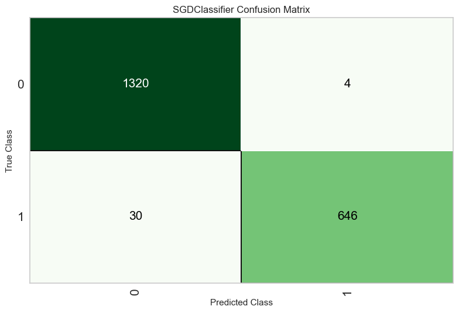

```python
# Hata matrisi (confusion matrix) ve diğer görselleştirme seçeneklerini inceleyelim.
plot_model(tuned_model, plot='confusion_matrix')
```

## Confusion Matrix Yorumlaması

- **1320**: Gerçekte “ham” olan 1320 mesaj doğru şekilde “ham” olarak sınıflandırılmış (**True Negative**).
- **4**: Gerçekte “ham” olan 4 mesaj yanlışlıkla “spam” olarak sınıflandırılmış (**False Positive**).
- **30**: Gerçekte “spam” olan 30 mesaj yanlışlıkla “ham” olarak sınıflandırılmış (**False Negative**).
- **646**: Gerçekte “spam” olan 646 mesaj doğru şekilde “spam” olarak sınıflandırılmış (**True Positive**).

### Öne Çıkan Bulgular

- Model “ham” mesajlarını yüksek doğrulukla tespit ediyor (False Positive sadece 4).
- “Spam” mesajları da büyük oranda doğru tahmin edilmiş (False Negative 30).
- **Kesinlik (Precision)** ve **Duyarlılık (Recall)** değerleri de yüksek seviyelerde seyrediyor (özellikle ham için neredeyse kusursuz, spam için de oldukça iyi).

Genel anlamda, bu sonuçlar modelin her iki sınıfı da başarılı bir şekilde ayırt ettiğini gösteriyor.

Ayrıca, `predict_model` fonksiyonu ile test seti üzerinde tahminler yapıp sonuçları inceleyebiliriz.

### 5.5 Final Modelin Oluşturulması ve Kaydedilmesi

Eğer tuning işlemi sonrası modeli onayladıysak, `finalize_model` fonksiyonu ile tüm veri üzerinde eğitilmiş final modelimizi oluşturuyoruz.  
Bu model, gerçek dünya uygulamalarında kullanılmak üzere saklanabilir.

```python
# Final modelin oluşturulması
final_model = finalize_model(tuned_model)

# (İsteğe bağlı) Modeli dosyaya kaydetmek için:
from pycaret.classification import save_model
# Modeli "models" klasörüne kaydetme
model_save_path = str(models_dir / "final_pycaret_model")
save_model(final_model, model_save_path)
```

```
Transformation Pipeline and Model Successfully Saved
```

[output not shown]

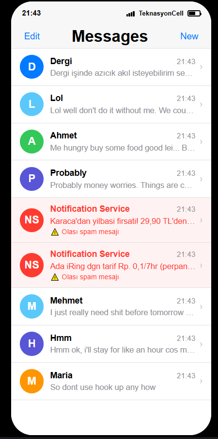

## Adım 6: Uygulama Geliştirme

# SMS Spam Detection Uygulaması - Geliştirme Adımları

## 1. Backend Geliştirmeleri

### 1.1 Flask Uygulama Yapısı

- **Flask Application Factory Pattern:**  
  Uygulama, modüler ve ölçeklenebilir olması amacıyla application factory pattern kullanılarak geliştirildi.
- **Blueprint'ler:**  
  Modüler yapı sağlamak amacıyla farklı fonksiyonellikler için blueprint'ler oluşturuldu.
- **Hata Yönetimi ve Loglama:**  
  Uygulama genelinde hata yönetimi ve loglama mekanizmaları eklendi.

### 1.2 Model Entegrasyonu

- **PyCaret Modeli ve TF-IDF Vektörleyici:**  
  PyCaret kullanılarak eğitilen model ve TF-IDF vektörleyici entegre edildi.
- **Model Yükleme ve Tahmin Fonksiyonları:**  
  Modelin yüklenmesi ve SMS mesajlarının spam/ham sınıflandırmasını yapacak tahmin fonksiyonları yazıldı.
- **Gerçek SMS Veri Seti Entegrasyonu:**  
  `sms_spam_train.csv` veri seti kullanılarak gerçek mesaj örnekleri uygulamaya entegre edildi.

### 1.3 API Endpoint'leri

- **`/` (Ana Sayfa):**  
  Uygulamanın ana sayfasını render eden endpoint.
- **`/get_message`:**  
  Rastgele SMS mesajı seçip, model üzerinden spam/ham sınıflandırması yaparak JSON formatında sonuç döndüren endpoint.

## 2. Frontend Geliştirmeleri

### 2.1 iPhone Benzeri Arayüz

- **iOS Tasarım Prensipleri:**  
  Apple’ın iOS tasarım prensipleri göz önünde bulundurularak kullanıcı arayüzü geliştirildi.
- **SF Pro Text Fontu:**  
  Gerçekçi bir iPhone görünümü için SF Pro Text fontu kullanıldı.
- **Gerçekçi iPhone Görünümü:**  
  Mobil cihazlarda iPhone benzeri, modern ve şık bir arayüz oluşturuldu.

### 2.2 Durum Çubuğu (Status Bar)

- **Gerçek Zamanlı Saat Gösterimi:**  
  Durum çubuğunda güncel saat bilgisi anlık olarak gösteriliyor.
- **Hücresel Sinyal Göstergesi:**  
  Hücresel sinyal durumu simgesi yer alıyor.
- **Operatör İsmi:**  
  Örneğin, “TeknasyonCell” operatör ismi gösteriliyor.
- **Pil Seviyesi Göstergesi:**  
  Pil durumu bilgisi de durumu yansıtan bir gösterge ile sunuluyor.

### 2.3 Mesajlar Listesi

- **iOS Messages Uygulaması Tarzında Liste Görünümü:**  
  Mesajlar, iOS Messages uygulamasına benzer liste görünümüyle sunuluyor.
- **Her Mesaj İçin:**
  - **Renkli Avatar:** Gönderici baş harfleriyle oluşturulan renkli avatar.
  - **Gönderici İsmi:** Mesajı gönderen kişinin veya servis adının gösterilmesi.
  - **Mesaj Önizlemesi:** Mesajın kısa bir önizlemesi.
  - **Zaman Bilgisi:** Mesajın gönderildiği saat bilgisi.
  - **Sağ Ok (Chevron) İşareti:** Mesaja tıklanabilirlik ve detaylı görünüm için sağ ok simgesi.

### 2.4 Spam Mesaj Gösterimi

- **Özel Tasarım:**  
  Spam mesajlar için özel bir görünüm uygulanmış:
  - Kırmızımsı arka plan.
  - Uyarı ikonu (⚠️).
  - "Olası spam mesajı" etiketi.
  - Kırmızı renkli metin kullanımı.

### 2.5 Akıllı İsimlendirme Sistemi

- **Gönderici İsim Ataması:**
  - **Spam Mesajlar:** Servis isimleri (örn. "VakıfBank", "Kampanya Servisi") kullanılıyor.
  - **Normal Mesajlar:** Gerçek kişi isimleri atanıyor.
- **İçerik Analizi:**  
  Mesaj içeriğine göre otomatik olarak isim seçimi yapılıyor.

### 2.6 Animasyonlar ve Etkileşimler

- **Yeni Mesaj Animasyonu:**  
  Yeni gelen mesajlar yumuşak geçiş animasyonları ile ekranda beliriyor.
- **Dokunma Geri Bildirimleri:**  
  Kullanıcı dokunuşlarında görsel geri bildirimler sağlanıyor.
- **Yumuşak Geçişler:**  
  Genel arayüzde estetik ve kullanıcı dostu yumuşak geçiş efektleri kullanıldı.

## 3. Özellikler

### 3.1 Mesaj İşleme

- **Rastgele Mesaj Seçimi:**  
  Gerçek SMS veri setinden rastgele mesajlar seçiliyor.
- **Spam/Ham Sınıflandırması:**  
  Model, mesajların spam veya ham olduğunu belirliyor.
- **Akıllı Gönderici Ataması:**  
  Mesaj içeriğine göre gönderici isimleri otomatik olarak atanıyor.

### 3.2 Kullanıcı Arayüzü

- **"New" Butonu:**  
  Kullanıcı, yeni mesaj almak için "New" butonuna tıklayabiliyor.
- **"Edit" Butonu:**  
  Görsel amaçlı düzenleme butonu mevcut.
- **Kaydırılabilir Mesaj Listesi:**  
  Mesajlar, kullanıcı dostu kaydırılabilir bir liste halinde sunuluyor.
- **Özelleştirilmiş Kaydırma Çubuğu:**  
  Arayüz, modern ve estetik bir kaydırma çubuğuna sahip.

### 3.3 Duyarlı Tasarım

- **Mobil Cihazlara Uyumlu Tasarım:**  
  Uygulama, farklı mobil cihazlarda optimum kullanıcı deneyimi sunacak şekilde responsive tasarlandı.
- **Retina Ekranlar için Optimize:**  
  Grafikler ve ikonlar, yüksek çözünürlüklü retina ekranlar için optimize edildi.
- **Modern iOS Görünümü:**  
  Genel görünüm, modern ve şık bir iOS arayüzüne benzetildi.

## 4. Teknik Detaylar

### 4.1 Kullanılan Teknolojiler

- **Backend:** Flask
- **Makine Öğrenmesi Modeli:** PyCaret
- **Frontend:** HTML5, CSS3, JavaScript
- **Veri İşleme:** Pandas

### 4.2 Performans İyileştirmeleri

- **Önbellekleme Mekanizmaları:**  
  Sık kullanılan veriler için cache kullanımı.
- **Lazy Loading:**  
  Gereksiz yüklemelerin önüne geçmek için lazy loading uygulanması.
- **Optimize Edilmiş Animasyonlar:**  
  Animasyon ve geçiş efektlerinin performansı artıracak şekilde optimize edilmesi.

### 4.3 Kod Organizasyonu

- **Modüler Yapı:**  
  Kod, fonksiyonelliklere göre modüler yapıda organize edildi.
- **Clean Code Prensipleri:**  
  Kod yazımında okunabilirlik ve sürdürülebilirlik hedeflendi.
- **Açıklayıcı Değişken İsimleri:**  
  Anlaşılır ve açıklayıcı isimlendirme standartları kullanıldı.
- **Detaylı Kod Yorumları:**  
  Her önemli bölüm ve fonksiyon için açıklayıcı yorumlar eklendi.